# Programming Workshop for Beginners

# Matplotlib

- our friend for visualizing data in Python!

```python
import matplotlib.pyplot as plt
```

# Plotting squares

```python
line = np.arange(5)
print('Line:', line)
squared_line = line**2
print('Squared line:', squared_line)
```

```
Line: [0 1 2 3 4]
Squared line: [ 0  1  4  9 16]
```

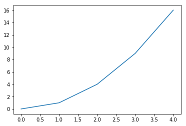

```python
plt.figure()
plt.plot(line, squared_line)
plt.show()
```

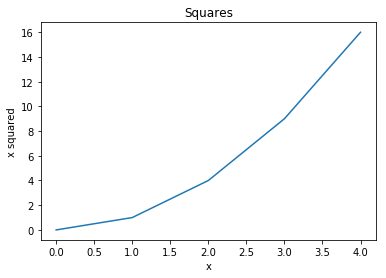

```python
plt.figure()
plt.title('Squares')
plt.plot(line, squared_line)
plt.xlabel('x')
plt.ylabel('x squared')
plt.show()
```

## Plotting: chocolate over happiness

```python
chocolate = np.loadtxt('chocolate.csv', delimiter=',', skiprows=1)
number_of_chocolates = chocolate[:, 0]
happiness = chocolate[:, 1]
```

## Plotting: chocolate over happiness

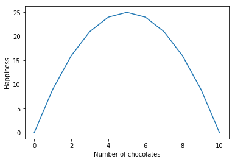

```python
plt.figure()
plt.plot(number_of_chocolates, happiness)
plt.xlabel('Number of chocolates')
plt.ylabel('Happiness')
plt.savefig('chocolate.png')
plt.show()
```

## Another kind of plot (just for fun!)

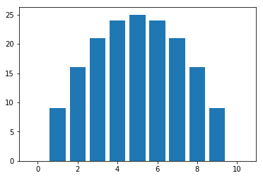

```python
plt.figure()
plt.bar(number_of_chocolates, happiness)
plt.show()
```

## Exercise

1. Add labels to the plot
2. Find a way to change the color of the bars (use help, either Google or "?" in IPython)
3. Make the bars thinner
4. Harder: Change the background color

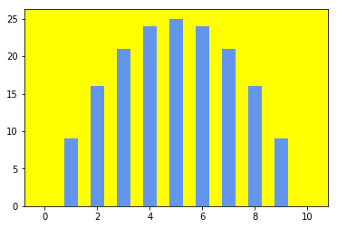

```python
plt.figure()
plt.subplot('111', facecolor='yellow')
plt.bar(number_of_chocolates, happiness, color='cornflowerblue', width=0.5)
plt.show()
```

## Even more fancy plots

Matplotlib gallery:

http://matplotlib.org/gallery.html

## Project time!

The project: https://github.com/uwpyb/materials/blob/master/projects/Day2_DataAnalysis.ipynb

Or a shorter link: https://goo.gl/7aRpZZ

We'll be back with demos and a short wrap-up discussion (i.e., what next?) at around 16:15!

## What's next?

- We will send you more information about the next steps
  - there are **many** things we did not cover, or mention
- Take advantage of CS courses at the Uni: CS 116 is also using Python (has a prerequisite CS115)

## Thanks!

Lunches and coffee breaks provided by:

- Women in Computer Science @ UW and Python Software Foundation:

[figure not shown]

- And many `<3` people all over the world who write programs for free, so other people can use them and do awesome things!

Help us to continue doing what we do by filling out the short survey! (you'll receive the link today)

### Graphics attributions

Front graphics, cookies image: [Graphics Provided by www.Vecteezy.com](https://www.vecteezy.com)